# COVID-19 in Newfoundland and Labrador

Amy Hurford, Zahra Mohammadi, and Francis Anokye

[Memorial University of Newfoundland and Labrador,](https://www.mun.ca/math/) [University of Guelph,](https://mathstat.uoguelph.ca/) [Canadian Network for Modelling Infectious Disease,](https://canmod.net/) [Mathematics for Public Health,](http://www.fields.utoronto.ca/activities/public-health) [One Health Modelling Network for Emerging Infections](https://www.yorku.ca/science/cdm/2021/04/09/ccdm-network-to-model-emerging-infectious-diseases-receives-2-5-million-in-federal-funding/)

On this website we:

- visualize COVID-19 cases reported by [Newfoundland and Labrador (NL)](https://www.gov.nl.ca/releases/covid-19-news/);
- estimate the doubling time of reported cases; and
- predict hospitalizations and deaths.

The data begins on December 15, 2021, when the [first Omicron case](http://ntv.ca/province-confirms-first-case-of-omicron-variant-introduces-new-public-health-measures/) was reported in NL.

## Data limitations

On January 12, Dr. Rahman presented the provincial modelling. Some of Dr. Rahman’s graphs considered [specimen date](https://twitter.com/PeterCBC/status/1481323100163784708) rather than report date. These data, by specimen date, are a more accurate representation of the COVID-19 outbreak in NL. This website considers only report date as specimen dates are not reported in the Public Service Advisories.

## Testing

[Recommendations for PCR testing](https://www.gov.nl.ca/releases/2022/health/0103n02/) changed in NL on January 3rd, 2022, such that anyone that is a close contact of a case and has symptoms of COVID-19, should consider themselves a positive case and not schedule a PCR test. In British Columbia (BC), people under 65 are discouraged from seeking PCR testing. The [BC Modelling Group](https://bccovid-19group.ca/post/2022-01-06-report/COVID19group-2022-01-06.pdf) estimates that the number of cases reported in BC would be 3.6 times higher without this change in testing.

To assess the impact of the change in PCR testing recommendations, we assumed that the number of tests reported for NL on a given day is the sum of two components:

$a_1$ or $a_2$: the number of tests arising due to a contact with a COVID-19 case reported 3 days earlier, and $b$: the number of tests performed per person in NL;

where $a_1$ is prior to January 6, and $a_2$ is after January 6th. We assume a 3 day lag between testing and reporting, such that if on January 3 symptomatic contacts of a case did not get tested the effect would first appear in the reporting on January 6. Using the data from the [Public Service Annoucements](https://www.gov.nl.ca/releases/covid-19-news/) we estimate that:

$a_1=$ 4.78 tests per case 3 days prior (to January 3)

$a_2=$ 1.5 tests per case 3 days prior (after January 3)

$b=$ 0.004 tests per person in NL.

This suggests that after January 3rd, 3.28 fewer tests were performed per case because symptomatic contacts of cases did not get tested.

This statistical model has poor fit and there are better sources of data than the [Public Service Announcements](https://www.gov.nl.ca/releases/covid-19-news/). Because the adjustment for changes to PCR testing are important, future updates will include a more thorough analysis of the testing data including visualization of the fit.

### Adjusted cases: correcting for the PCR testing changes and out-of-province test results

To correct for the change in PCR testing recommendations (beginning January 3), we assume that beginning January 6th the reporting reflects 3.28 fewer tests per case, and that all these tests that did not occur would have been positive. We use this adjustment so that reported cases can be compared before and after January 6. As the estimates of $a_1$ and $a_2$ are not significant, we also consider a low and high estimate of $a_1 - a_2$ (low: 1, high: 5 fewer tests per case after Jan 3).

[On January 10, 2022, NL reported 680 cases](https://www.gov.nl.ca/releases/2022/health/0110n04/) arising from tests sent out of province December 29 to January 6th. The numbers from the [Public Service Announcement](https://www.gov.nl.ca/releases/2022/health/0110n04/) suggest that all 680 cases were in Eastern Health. To correct the case data these 680 cases are distributed in Eastern Health in proportion to the number of reported cases on each day December 29 to January 6th. The addition of these cases is after the correction for the PCR testing change.

Cases from out-of-province testing have also been reported on the days after January 10. These cases are redistributed similarly, where the January 11 cases are distributed from December 30 to January 7th, and January 12th cases are distributed from December 31 to January 8th, and so forth.

All subsequent calculations are performed on the adjusted data.

## Adjusted cases

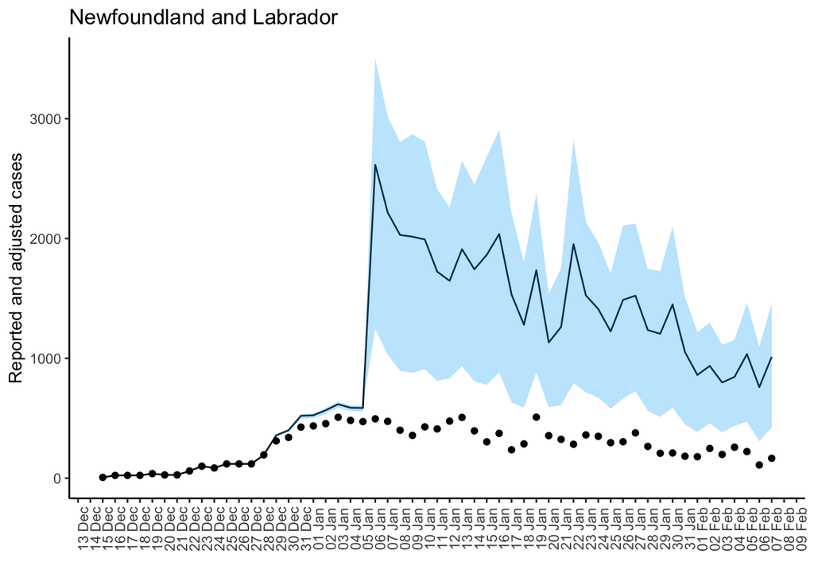

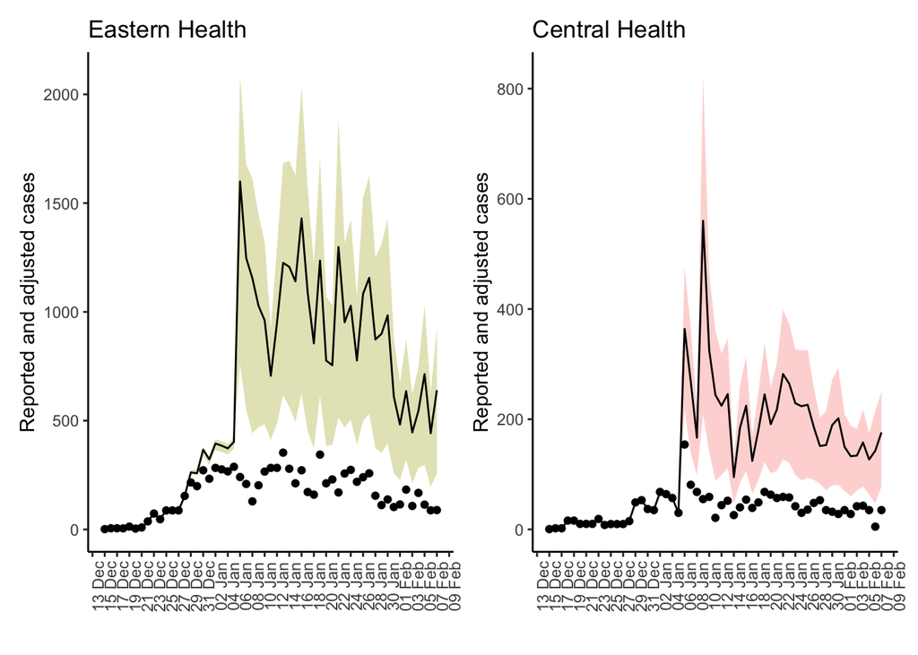

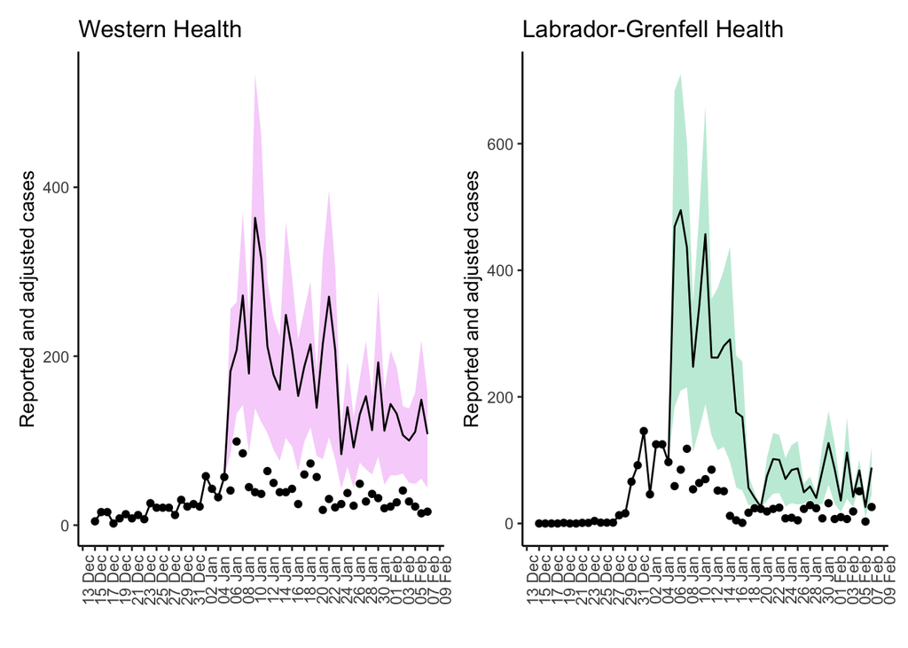

**Figure 1.** The adjustment for the PCR testing change and out-of-province reporting (line) and reported cases (dots). The shaded regions span from 1 to 5 fewer tests per case after Jan 3.

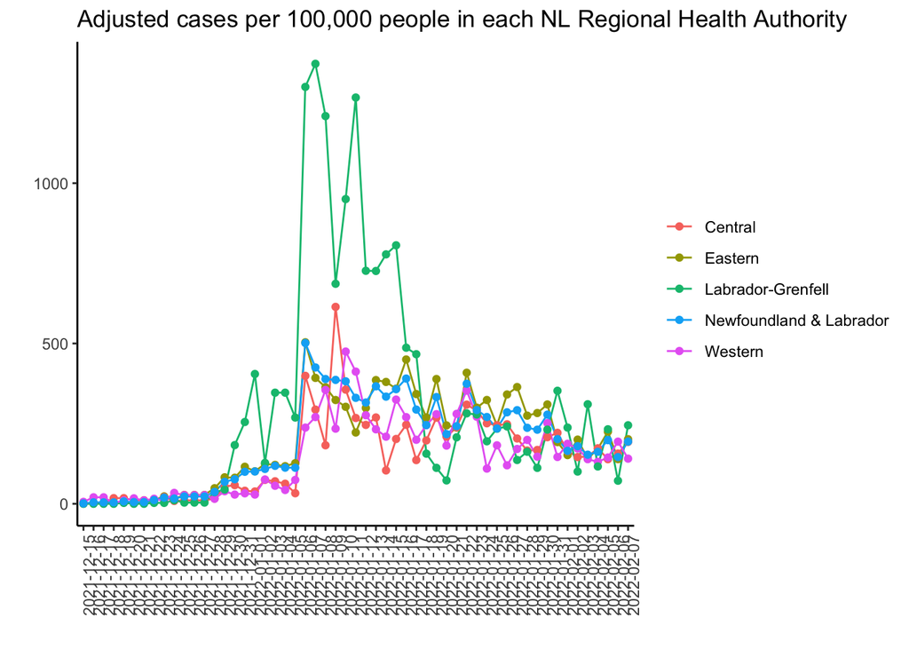

**Figure 2.** Data is adjusted for the changes to PCR testing and the reporting of testing performed out-of-province.

## Doubling and halving times

The doubling time is the days until the number of reported cases doubles (assuming exponential growth). The halving time is the days until the number of reported cases halves (assuming exponential decay). Our doubling and halving time calculations consider the number of reported cases over the last 14 days. If the exponential growth coefficient is not different from 0, the number of reported cases is stated as ‘level’.

**Newfoundland and Labrador:** decreasing with a halving time of 15.76 days

**Eastern Health:** decreasing with a halving time of 12.29 days

**Central Health:** decreasing with a halving time of 21.21 days

**Western Health:** level

**Labrador-Grenfell Health:** level

Fitting is performed using nonlinear least squares and considers the adjusted data.

## Hospitalizations and deaths

We consider data from [United Kingdom Health Security Agency (UKHSA)](https://assets.publishing.service.gov.uk/government/uploads/system/uploads/attachment_data/file/1044481/Technical-Briefing-31-Dec-2021-Omicron_severity_update.pdf) and [Public Health Ontario (PHO)](https://www.publichealthontario.ca/-/media/documents/ncov/epi/covid-19-epi-enhanced-estimates-omicron-severity-study.pdf?sc_lang=en) reports to understand the relationship between reported Omicron cases and the future number of hospitalizations and deaths.

The UKHSA study reports for confirmed Omicron cases: 198,348 cases, 815 hospital admissions (0.41%), and 57 deaths (0.03%) up until December 29, 2021. The PHO study reports for Omicron: 29,594 cases, 75 hospitalizations or deaths (0.25%), and 3 deaths (0.01%) from November 22 - December 17, 2021.

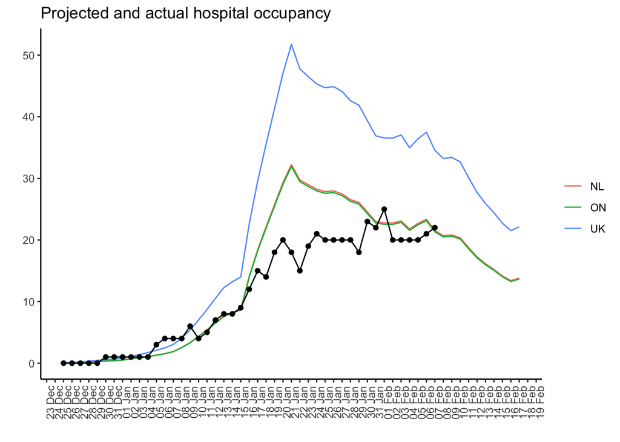

**Figure 3.** The black dots and lines are the number of people in hospital as reported by the NL [Public Advisories](https://www.gov.nl.ca/releases/covid-19-news/). We assume hospitalizations are lagged 10 days from cases and the length of stay in hospital is 7 days. Hospital occupancy when assuming the reported proportion of hospitalizations for Omicron cases in the UKHSA (blue) and PHO (green) studies. The calibration to the NL data (red) assumes 0.26% of reported cases are hospitalized. These calculations consider the adjusted case data. Note that the ranking of hospitalization rates is sensitive to the assumed average length of stay in hospital. We are not aware of a reported value for the average length of stay in hospital for Newfoundland and Labrador during the Omicron wave.

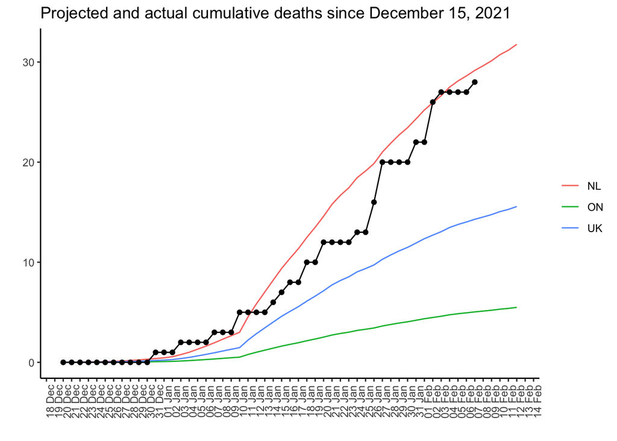

**Figure 4.** The black dots and lines are the number of deaths as reported by the NL [Public Advisories](https://www.gov.nl.ca/releases/covid-19-news/). We assume the time from being reported as a case to death is 5 days, which is the median time from specimen to death in the UKHSA study. Cumulative deaths since December 15, 2021 when assuming the reported proportion of deaths for Omicron cases in the UKHSA (blue) and PHO (green) studies. The calibration to the NL data (red) assumes that death occurs for 0.06% of reported cases. These calculations consider the adjusted case data. The [following](https://twitter.com/Aaron_Derfel/status/1486670800279195648/photo/1) suggests a different mortality rate for Ontario relative to NL. We will look into this at a later date.